# Improving Marketing Efficiency Using Predictive Analytics

MSIN0094 Case Study

Author

Affiliation

Dr Wei Miao

UCL School of Management

Published

October 25, 2023

# 1 Predictive Analytics and Marketing[^1]

Marketing research has traditionally focused on causal inference. The focus on causation stems from the need to make counterfactual predictions. For example, will increasing advertising expenditure increase demand? Answering this question requires an unbiased estimate of advertising impact on demand. However, the need to make accurate predictions is also important to marketing practices. For example, which consumers to target, which product configuration a consumer is most likely to choose, which version of a banner advertisement will generate more clicks, and what the market shares and actions of competitors are likely to be. All of these are prediction problems. These problems do not require causation; rather, they require models with high out-of-sample predictive accuracy. Predictive analytics (machine learning, ML) tools can address these types of problems.

Machine learning (ML) refers to the study of methods or algorithms designed to learn the underlying patterns in the data and make predictions based on these patterns. A key characteristic of predictive analytics techniques is their ability to produce accurate out-of-sample predictions. Consider the problem of predicting whether a user will click on an ad. We do not have a comprehensive theory of users’ clicking behavior. Predictive analytics methods can automatically learn which of these factors affect user behavior and how they interact with each other, potentially in a highly non-linear fashion, to derive the best functional form that explains user behavior virtually in real time. Predictive analytics methods typically assume a model or structure to learn, but they use a general class of models that can be very rich.

Predictive analytics models can be divided into two groups: supervised learning and unsupervised learning. Supervised learning requires input data that has both predictor (independent) variables and a target (dependent) variable whose value is to be estimated. If the goal of an analysis is to predict the value of some variable (e.g., whether customer responds to our marketing offers; whether customers churn at some point in time), then supervised learning is used.

On the other hand, unsupervised learning does not identify a target (dependent) variable, but rather treats all of the variables equally. In this case, the goal is not to predict the value of a variable, but rather to look for patterns, groupings, or other ways to characterize the data that may lead to an understanding of the way the data interrelate. Cluster analysis is an example of unsupervised learning, which helps data analysts find customer segments based on provided characteristics.

In this case study, we are going to analyze the same dataset as in “Preliminary Customer Analysis”. Our task is to use predictive analytics tools to help Tesco conduct more effective targeted marketing.

As a quick recap, the variable definitions are as follows:

**Demographic Variables**

- ID: Customer’s unique identifier
- Year_Birth: Customer’s birth year
- Education: Customer’s education level
- Marital_Status: Customer’s marital status
- Income: Customer’s yearly household income
- Kidhome: Number of children in customer’s household
- Teenhome: Number of teenagers in customer’s household
- Dt_Customer: Date of customer’s enrollment with the company

**Customer Purchase History Data**

- ID: Customer’s unique identifier
- MntWines: Amount spent on wine in last 2 years
- MntFruits: Amount spent on fruits in last 2 years
- MntMeatProducts: Amount spent on meat in last 2 years
- MntFishProducts: Amount spent on fish in last 2 years
- MntSweetProducts: Amount spent on sweets in last 2 years
- NumDealsPurchases: Number of purchases made with a discount
- NumWebPurchases: Number of purchases made through the company’s web site
- NumCatalogPurchases: Number of purchases made using a catalogue
- NumStorePurchases: Number of purchases made directly in stores
- NumWebVisitsMonth: Number of visits to company’s web site in the last month
- Complain: 1 if customer complained in the last 2 years, 0 otherwise
- **Response: 1 if customer accepted the offer in the last campaign, 0 otherwise**
- Recency: Number of days since customer’s last purchase

# 2 Customer Segmentation Using Unsupervised Learning

## 2.1 **Marketing Objective**

We aim to do customer segmentation based on *total spending* and *income.*

## 2.2 **Data Collection**

```r
pacman::p_load(dplyr,modelsummary)
# Load both datasets
data_purchase <- read.csv(file = "https://www.dropbox.com/s/126e9vkq80y9ti9/purchase.csv?dl=1",
                      header = T)

data_demo <- read.csv("https://www.dropbox.com/s/hbrgktcz98y0igs/demographics.csv?dl=1",
                      header = T)

# Left join demographic data into purchase data
data_full <- data_purchase %>%
  left_join(data_demo, by = c("ID" = "ID") )
```

## 2.3 **Data Cleaning**

First, we need to check missing values and resolve them as the k-means algorithm cannot handle missing values directly.

```r
# check missing values for each variable
datasummary_skim(data_full)
```

Unique (#)

Missing (%)

Mean

SD

Min

Median

Max

ID

2000

0

5599.2

3242.0

0.0

5492.0

11191.0

MntWines

738

0

306.1

338.3

0.0

176.5

1493.0

[figure not shown]

MntFruits

157

0

26.4

39.9

0.0

8.0

199.0

MntMeatProducts

532

0

167.9

225.3

0.0

68.0

1725.0

MntFishProducts

179

0

37.6

54.6

0.0

12.0

259.0

MntSweetProducts

175

0

27.5

41.8

0.0

8.0

263.0

[figure not shown]

MntGoldProds

207

0

43.8

51.7

0.0

24.0

362.0

NumDealsPurchases

15

0

2.3

2.0

0.0

2.0

15.0

[figure not shown]

NumWebPurchases

15

0

4.1

2.8

0.0

4.0

27.0

[figure not shown]

NumCatalogPurchases

14

0

2.7

3.0

0.0

2.0

28.0

[figure not shown]

NumStorePurchases

14

0

5.8

3.3

0.0

5.0

13.0

NumWebVisitsMonth

15

0

5.3

2.5

0.0

6.0

20.0

Complain

2

0

0.0

0.1

0.0

0.0

1.0

Response

2

0

0.2

0.4

0.0

0.0

1.0

Year_Birth

59

0

1968.8

12.0

1893.0

1970.0

1996.0

Income

1783

1

52139.7

21492.4

1730.0

51518.0

162397.0

[figure not shown]

Kidhome

3

0

0.4

0.5

0.0

0.0

2.0

Teenhome

3

0

0.5

0.5

0.0

0.0

2.0

Recency

100

0

49.2

29.0

0.0

50.0

99.0

```r
data_full <- data_full %>%
  mutate(Income = ifelse(is.na(Income), # True of false
                         mean(Income,na.rm = T), # if true, then use mean income
                         Income)) # if false, still the same value
```

Second, we need to re-scale the two variables using `scale()`, because the two variables are of very different scales.

```r
data_kmeans <- data_full%>%
  mutate(total_spending = MntFishProducts + MntFruits + MntGoldProds + MntMeatProducts + MntSweetProducts + MntWines) %>%
  select(Income,total_spending)%>%
  mutate(Income = scale(Income),
         total_spending = scale(total_spending))
```

## 2.4 Data Analytics

- Run the K-means clustering algorithm using `kmeans()`

```r
set.seed(888)
result_kmeans <- kmeans(data_kmeans,
                        centers = 2,
                        nstart = 10)
```

- We can examine the structure of the `result_kmeans` using `str()`

```r
str(result_kmeans)
```

```
List of 9
 $ cluster     : int [1:2000] 1 2 1 2 2 1 2 2 2 2 ...
 $ centers     : num [1:2, 1:2] 0.95 -0.663 1.022 -0.713
  ..- attr(*, "dimnames")=List of 2
  .. ..$ : chr [1:2] "1" "2"
  .. ..$ : chr [1:2] "Income" "total_spending"
 $ totss       : num 3998
 $ withinss    : num [1:2] 726 553
 $ tot.withinss: num 1280
 $ betweenss   : num 2718
 $ size        : int [1:2] 822 1178
 $ iter        : int 1
 $ ifault      : int 0
 - attr(*, "class")= chr "kmeans"
```

- Summarize the model object by printing it

```r
result_kmeans
```

```
K-means clustering with 2 clusters of sizes 822, 1178

Cluster means:
      Income total_spending
1  0.9501963      1.0222565
2 -0.6630402     -0.7133233

Clustering vector:
   [1] 1 2 1 2 2 1 2 2 2 2 2 2 1 2 2 1 2 2 1 2 2 2 1 1 2 2 2 2 2 1 2 2 2 2 1 2 1
  [38] 2 2 1 1 2 2 2 2 1 2 2 2 1 1 1 2 1 1 1 1 2 2 2 1 1 1 1 1 2 2 1 1 1 1 2 1 1
  [75] 2 2 1 1 2 1 2 2 2 2 1 2 2 2 1 2 2 2 1 2 2 2 2 2 1 2 2 2 1 1 1 2 2 1 2 1 1
 [112] 1 2 1 2 2 1 2 2 2 2 2 2 2 1 1 1 2 2 1 2 1 1 2 2 1 2 2 2 2 1 1 1 1 2 1 2 2
 [149] 2 2 2 1 2 2 1 1 2 2 2 1 2 1 2 1 1 2 2 2 1 2 2 2 2 2 2 1 1 2 2 1 2 2 1 2 2
 [186] 2 2 1 1 2 2 1 2 2 2 2 1 1 1 2 1 1 1 1 2 2 2 2 2 1 2 1 2 2 1 2 2 1 2 1 2 1
 [223] 1 2 1 2 2 1 1 2 2 1 2 2 1 2 2 1 2 2 1 1 2 1 1 2 1 1 1 1 2 2 1 2 1 2 1 2 2
```

[output cut: 57 more lines]

- Visualize the clustering

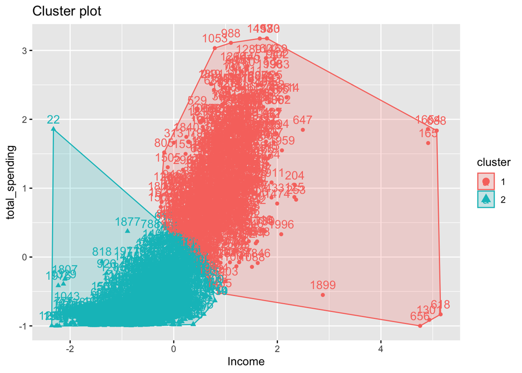

```r
pacman::p_load(cluster,factoextra)
set.seed(888)
fviz_cluster(result_kmeans,
             data = data_kmeans)
```

- Determine the optimal number of clusters using statistical criteria

**Gap Method**

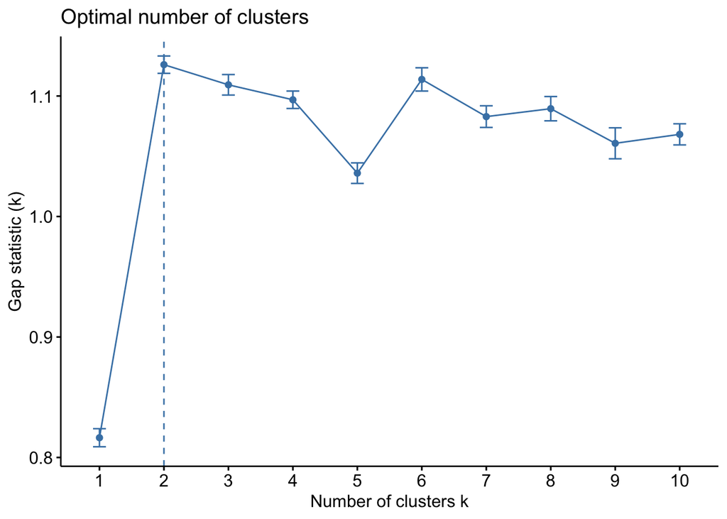

```r
set.seed(888)
gap_stat <- clusGap(data_kmeans,
                    FUN = kmeans,
                    K.max = 10,
                    B = 50)
fviz_gap_stat(gap_stat)
```

**Silhouette method**

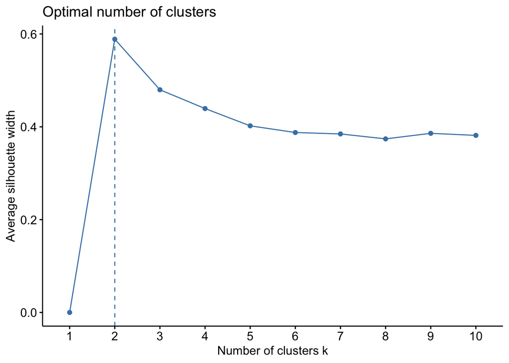

```r
set.seed(888)
fviz_nbclust(data_kmeans, kmeans, method = "silhouette")
```

From both methods, it seems K = 2 is the best choice.

## 2.5 Business Recommendations

As we would like to save marketing costs by sending marketing offers to responsive customers, we need to compute the average response rate for each segment generated by the K-means algorithm

- Generate the customer segment in `data_full`

```r
data_full <- data_full %>%
  mutate(segment = result_kmeans$cluster)
```

- Compute the average response rate for each segment

```r
data_full %>%
  group_by(segment) %>%
  summarise(avg_response_rate = mean(Response, na.rm = T)) %>%
  ungroup()
```

| segment | avg_response_rate |
| --- | --- |
| 1 | 0.2165450 |
| 2 | 0.1044143 |

We observe that Segment 1 has a much higher average response rate of more than 20%, so we should send marketing offers to Segment 1 customers.

# 3 Customer Targeting using Supervised Learning Tasks

## 3.1 Marketing objective

Tesco is looking to promote its new [private-label](https://en.wikipedia.org/wiki/Private_label) products to existing customers. The marketing analytics team decides to use the conventional mailing marketing strategy so that customers would receive color-printed leaflets via Royal Mails to their doorsteps.

Each mail costs £1.5 to produce and another £0.5 to mail to the customers. If a customer responds to the offer, the data analytics team expects customers to spend £20 on trying the new products, where the COGS is 60%.

In this case study, we will learn how Tesco can use the power of predictive analytics to greatly improve its marketing efficiency and [return on investment](https://www.investopedia.com/articles/personal-finance/053015/how-calculate-roi-marketing-campaign.asp). Whether a customer responded to our marketing offer in the last marketing campaign is recorded in the `Respone` variable in the dataset.

## 3.2 Break-Even Analysis for Making Marketing Offers

First, we need to compute the profit margin (the net profit) if a customer responds to the marketing offer and buys from Tesco.

```r
cost_per_offer <- 1.5 + 0.5

COGS <- 0.6
profit_per_customer <- 20 * (1 - COGS)
```

Second, compute the break-even response rate for a customer.

- The cost is the marketing offer we send, `cost_per_offer`
- The benefit is the profit margin if a customer responds, `profit_per_customer`
- In order to break-even, we can calculate the break-even response rate from customers:

```r
break_even_response <- cost_per_offer/profit_per_customer
break_even_response
```

```
[1] 0.25
```

Which means, only if a customer responds to us with at least 25% response rate can we recover the costs of making an marketing offer.

## 3.3 Data collection and cleaning

*Tasks*: Merge the demographic information into purchase history data.

```r
pacman::p_load(dplyr)
# Load both datasets
data_purchase <- read.csv(file = "https://www.dropbox.com/s/126e9vkq80y9ti9/purchase.csv?dl=1",
                      header = T)

data_demo <- read.csv("https://www.dropbox.com/s/hbrgktcz98y0igs/demographics.csv?dl=1",
                      header = T)

# Left join demographic data into purchase data
data_full <- data_purchase %>%
  left_join(data_demo, by = "ID")

# Handle Missing Values of Income
data_full <- data_full %>%
  mutate(Income = ifelse(is.na(Income),
                         mean(Income,na.rm =T),
                         Income)) %>%
  mutate(totalspending = MntFishProducts + MntFruits + MntGoldProds + MntMeatProducts + MntSweetProducts + MntWines)
```

## 3.4 Data Analytics Using Supervised Machine Learning

### 3.4.1 Select meaningful features/predictors from `data_full`, named `data_full_small`

- Since `ID` is customer ID only, so should be removed from final data
- Since `Dt_Customer` is a character string, which cannot be directly used in the model, we should also remove it

```r
# Use select to remove the above two variables
# Tip: a minus sign before the variable name can remove that variable

data_full_smaller <- data_full %>%
  select(-ID) %>%
  select(-Dt_Customer)
```

### 3.4.2 Construct a training set and a test set

*Tasks*: randomly divide `data_full` into a training set and a test set

```r
# use nrow() to count the number of rows in data_full_smaller
n_rows_data_full <- nrow(data_full_smaller)

# set a seed, so that we can get the same set of results every time we rerun the model
set.seed(8888)

# use sample() to randomly draw row index from data_full
training_index <- sample(x = 1:n_rows_data_full, # draw from 1 until 2000
                         size  = 0.7 * n_rows_data_full, # size is 70% of 2000
                         replace = FALSE) # do not sample with replacement

# think of data_full_smaller as a matrix, we can select rows based on training_index
data_training <- data_full_smaller[training_index,]

# minus sign means deselecting rows
data_test <- data_full_smaller[-training_index,]
```

### 3.4.3 Train a decision tree

*Tasks*: load the `rpart` and `rpart.plot` packages. Follow the code examples in the lecture notes and try to train a decision tree on `data_training`

```r
pacman::p_load(rpart,rpart.plot)

# write your codes below from what we learned in class.

decision_tree <- rpart(
  formula = Response ~ MntWines + MntFruits + MntMeatProducts + MntFishProducts +
    MntSweetProducts + MntGoldProds + NumDealsPurchases + NumWebPurchases + NumCatalogPurchases +
    NumStorePurchases + NumWebVisitsMonth + Complain + Year_Birth + Education +
    Marital_Status + Income + Kidhome + Teenhome + Recency,
  data =  data_training,
  method  = "anova" ) # because we need probabilities (a continuous variable) later on to decide targeting, here we sepcify "anova" rather than "class"
```

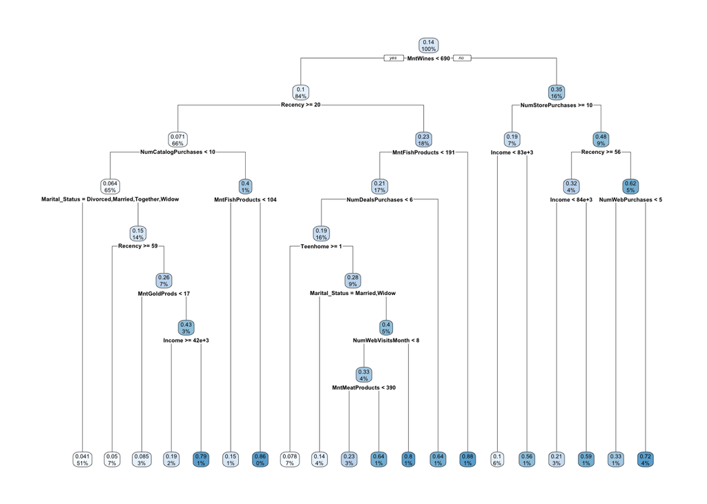

```r
# visualize the decision tree we have built
rpart.plot(decision_tree)
```

### 3.4.4 Train a random forest

*Tasks*: load the `ranger` packages. Follow the code examples in the lecture notes and try to train a random forest on `data_training`

```r
pacman::p_load(ranger)

# write your codes below:

set.seed(888)
randomforest <- ranger(
  formula = Response ~  MntWines + MntFruits + MntMeatProducts + MntFishProducts +
    MntSweetProducts + MntGoldProds + NumDealsPurchases + NumWebPurchases + NumCatalogPurchases +
    NumStorePurchases + NumWebVisitsMonth + Complain + Year_Birth + Education +
    Marital_Status + Income + Kidhome + Teenhome + Recency,
  data = data_training,
  probability = TRUE,
  num.trees = 500
)

# make prediction on the test set, which returns a model prediction object
prediction_from_randomforest <- predict(randomforest, data_test)

# mutate a new column in data_test for the predicted probability from random forest
# the prediction_from_randomforest$predictions gives a matrix
# so we need to the take the second column using [,2]
data_test <- data_test %>%
  mutate(predicted_prob_randomforest = prediction_from_randomforest$predictions[,2])
```

## 3.5 Business Recommendations

### 3.5.1 Blanket marketing

If Tesco does blanket marketing and sends marketing offers to all 600 customers in the test set, the total marketing costs would be

```r
total_costs_of_mailing_blanket <- cost_per_offer * nrow(data_test)
total_costs_of_mailing_blanket
```

```
[1] 1200
```

And the total profits from the blanket marketing would be

```r
# below is the total number of responding customers in the test set
sum(data_test$Response)
```

```
[1] 99
```

```r
# Multiply it with profit_per_customer, we get total profits from the marketing campaign
total_profit_blanket <- sum(data_test$Response) * profit_per_customer
```

Therefore, the **Return on Investment** **(ROI)** on the marketing offer would be

**Return on Investment**

ROI = Net Profits / Initial Investments, which means the return rate of an investment activity.

- ROI needs to be a positive number in order for the company to make profits from the investment.

```r
# net profits = total_profit_blanket - total_costs_of_mailing_blanket
# initial investment = total_costs_of_mailing_blanket
# So ROI is below:

ROI_blanket <- (total_profit_blanket - total_costs_of_mailing_blanket)/total_costs_of_mailing_blanket

ROI_blanket
```

```
[1] -0.34
```

A negative ROI from blanket marketing means, the company makes a loss from sending offers to all customers in the test set. The reason is that, not all customers are responsive to our marketing offers. It does Tesco no good from sending offers to those customers who would not respond anyway.

However, if Tesco uses the trained decision tree model to conduct targeted marketing, and **only target those customers who are predicted to be more responsive than the break-even response rate by decision trees**, what would happen to the ROI?

### 3.5.2 Predict response rate from decision tree model

First, we have already trained the decision tree model, named `decision_tree`, from the training set. We can predict the probability of test set customer responding to our marketing offer, using `predict()`.

```r
# use predict() to make prediction on the test set
# Note that prediction_from_decision_tree is already a vector,
# which we can directly mutate into
prediction_from_decision_tree <- predict(decision_tree, data_test)

# mutate a new column in data_test for the predicted probability
# note that from decision tree, predict() can directly give a vector rather than matrix
# so we no longer need to extract the second column (as we did with random forest)
data_test <- data_test %>%
  mutate(predicted_prob_decisiontree = prediction_from_decision_tree)
```

*Tasks*: We should only send marketing offers to consumers whose expected or predicted response rate is larger than the break-even response rate. This is called targeted marketing.

```r
# mutate a new binary indicator for whether to target a customer based on predicted prob from decision tree model
data_test <- data_test %>%
  mutate(is_target_decisiontree = ifelse(predicted_prob_decisiontree > break_even_response,1,0))
```

Finally, we have decided to send marketing offers to selected responsive customers. We can then compute the ROI for targeted marketing as in the blanket marketing case.

```r
# total marketing costs
total_costs_of_mailing_decisiontree <- cost_per_offer *  # cost per offer
  sum(data_test$is_target_decisiontree)  # the sum of is_target is the total number of customers who receive the offer

# filter out customers who receive the marketing offer
data_test_targeted_customers <- data_test%>%
     filter(is_target_decisiontree==1)

# total profits from responding customers

total_profit_decisiontree <- sum(data_test_targeted_customers$Response) * # sum up to get how many targeted customers actually responded
  profit_per_customer # the profit per responding customer

# Compute ROI
ROI_decisiontree<- (total_profit_decisiontree - total_costs_of_mailing_decisiontree)/total_costs_of_mailing_decisiontree

ROI_decisiontree
```

```
[1] 0.8550725
```

If Tesco uses random forest, an arguably better supervised learning model, to conduct targeted marketing, we can follow a similar logic as above, and compute the ROI from using random forest.

```r
# mutate a new binary indicator for whether to target a customer based on predicted prob from random forest model
data_test <- data_test %>%
  mutate(is_target_randomforest = ifelse(predicted_prob_randomforest > break_even_response,1,0))

# total marketing costs
total_costs_of_mailing_randomforest <- cost_per_offer * sum(data_test$is_target_randomforest)

# get the number of responding customers who are targeted: the second method

data_responding_targeted_customers <- data_test %>%
  filter(is_target_randomforest == 1) %>%  # who are targeted
  filter(Response == 1) # who responding among targeted customers

# total profits from responding customers
total_profit_randomforest <- nrow(data_responding_targeted_customers) * profit_per_customer

# Compute ROI
ROI_randomforest<- (total_profit_randomforest - total_costs_of_mailing_randomforest)/total_costs_of_mailing_randomforest

ROI_randomforest
```

```
[1] 1.110236
```

Predictive analytics model can help the company boost the marketing ROI by allowing Tesco to target customers who are more likely to respond to the marketing offers than the break-even response rate. By doing so, Tesco saves unnecessary marketing costs on those unresponsive customers and therefore improves its marketing efficiency.

## Footnotes

[^1]: This section is heavily borrowed from [Chapter 11 of Handbook of Marketing Analytics](https://ucl.primo.exlibrisgroup.com/permalink/44UCL_INST/18kagqf/cdi_proquest_ebookcentral_EBC5328483). For the full article, you can have assess via UCL library service.